# PEEP-II Behavioral Ratings

Rick Gilmore

2019-02-27 13:57:56

## Purpose

This notebook documents the process of exploring the PEEP-II ratings data.

## Preliminaries

Load libraries.

```r
library(tidyverse)
library(stringr)
```

## Copy data and import

The behavioral data are currently (2017-06-20-15:02) stored in `~/Box\ Sync/b-peep-project\ Shared/PEEP2\ data/PEEP2\ Home\ visit\ behavioural\ data/` as a set of `*.csv` files.

```r
peep2.data.dir <- "~/Box\ Sync/b-peep-project\ Shared/PEEP2\ data/PEEP2\ Home\ visit\ behavioural\ data/"
# List files and open one for inspection
peep2.flist <- list.files(path = peep2.data.dir, pattern = "\\.csv$", full.names = TRUE)
peep2.test.df <- read.csv(file = peep2.flist[1])
str(peep2.test.df)
```

```
'data.frame':   33 obs. of  11 variables:
 $ fam_id      : int  1 1 1 1 1 1 1 1 1 1 ...
 $ nov_id      : int  6 6 6 6 6 6 6 6 6 6 ...
 $ run         : int  1 1 1 1 1 1 1 1 1 1 ...
 $ order       : int  4 4 4 4 4 4 4 4 4 4 ...
 $ sound_index : int  1 2 3 4 5 6 7 8 9 10 ...
 $ snd_file    : Factor w/ 32 levels "wav/001/norm/001-ang-chk-a.wav",..: 27 8 17 32 11 18 5 16 26 1 ...
 $ happy_rating: int  2 4 1 1 1 1 1 1 1 1 ...
 $ angry_rating: int  2 1 4 2 2 4 3 2 2 2 ...
 $ sad_rating  : int  1 1 1 4 3 2 2 2 2 2 ...
 $ how_feel    : int  1 1 1 1 1 2 2 3 1 1 ...
 $ know_speaker: int  1 2 5 3 4 3 4 4 5 4 ...
```

```r
# Color palette for plotting dots
# 'neutral', 'happy', 'angry', 'sad', 'scared'
emo_colors <- c("black", "green", "red", "blue", "yellow")
```

It looks like the data files are well-structured and the variable names clear. **Note** that the ratings are on a [1,4] scale. I don’t recall what the `know_speaker` ratings reflect now, but I will check.

Let’s proceed to import the existing data and combine it into one file for visualization.

```r
peep2.df.list <- lapply(peep2.flist, read.csv)
peep2.df <- Reduce(function(x,y) merge(x,y, all =TRUE), peep2.df.list)
str(peep2.df)
```

```
'data.frame':   3358 obs. of  12 variables:
 $ fam_id       : int  1 1 1 1 1 1 1 1 1 1 ...
 $ nov_id       : int  6 6 6 6 6 6 6 6 6 6 ...
 $ run          : int  1 1 1 1 1 1 1 1 1 1 ...
 $ order        : int  4 4 4 4 4 4 4 4 4 4 ...
 $ sound_index  : int  1 2 3 4 5 6 7 8 9 10 ...
 $ snd_file     : Factor w/ 1728 levels "wav/001/norm/001-ang-chk-a.wav",..: 27 8 17 32 11 18 5 16 26 1 ...
 $ happy_rating : int  2 4 1 1 1 1 1 1 1 1 ...
 $ angry_rating : int  2 1 4 2 2 4 3 2 2 2 ...
 $ sad_rating   : int  1 1 1 4 3 2 2 2 2 2 ...
 $ how_feel     : int  1 1 1 1 1 2 2 3 1 1 ...
 $ know_speaker : int  1 2 5 3 4 3 4 4 5 4 ...
 $ scared.rating: int  NA NA NA NA NA NA NA NA NA NA ...
```

It looks like the `scared.rating` occurs in some of the later data files, but was not present in the first one we examined. Note that that we do not have a variable that specifies the target prosody {‘ang’, ‘hap’, ‘neu’, ‘sad’}, the script type {‘chk’, …}, or the script variation {‘a’, ‘b’}, but that these are available from the `snd_file` name. It should be relatively easy to pull those from the `snd_file` names. Let’s see.

```r
# Pick character ranges by hand
peep2.df$target_prosody <- str_sub(peep2.df$snd_file, 18, 20)
peep2.df$script_name <- str_sub(peep2.df$snd_file, 22, 24)
peep2.df$script_variation <- str_sub(peep2.df$snd_file, 26, 26)
```

We also need to identify whether the speaker is familiar or novel.

```r
this_spkr <- as.numeric(str_sub(peep2.df$snd_file, 14, 16))
peep2.df$speaker_fam <- (this_spkr == peep2.df$fam_id)
peep2.df$speaker_famnov <- 'nov'
peep2.df$speaker_famnov[peep2.df$speaker_fam] <- 'fam'
```

## Mapping between ratings and image icons

### Angry ratings

1

2

3

4

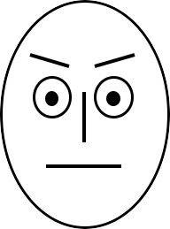

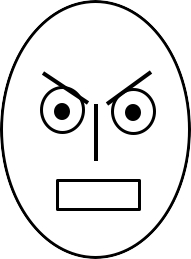

### Happy ratings

1

2

3

4

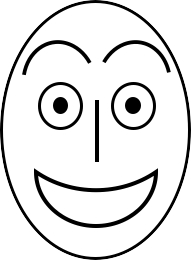

### Sad ratings

1

2

3

4

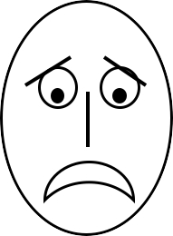

### Scared ratings

1

2

3

4

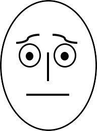

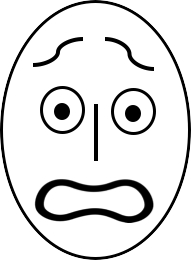

### How feel ratings

Neutral

Happy

Angry

Sad

Scared

1

2

3

4

5

## Angry prosody

### Angry ratings

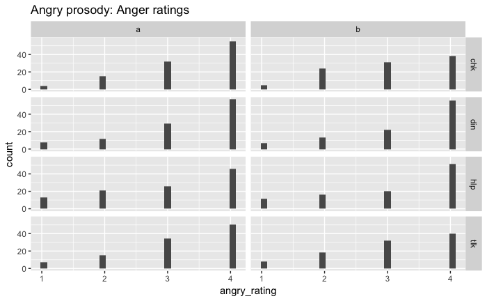

```r
peep2.df %>%
  filter(target_prosody %in% "ang") %>%
  ggplot() +
  # aes(x = script_name, y = angry_rating) +
  # geom_violin() +
  # facet_grid(. ~ script_variation) +
  aes(x = angry_rating) +
  geom_histogram() +
  facet_grid(script_name ~ script_variation) +
  ggtitle("Angry prosody: Anger ratings")
```

There is no obvious effect of the `script_name` or `script_variation`. Let’s look at familiarity.

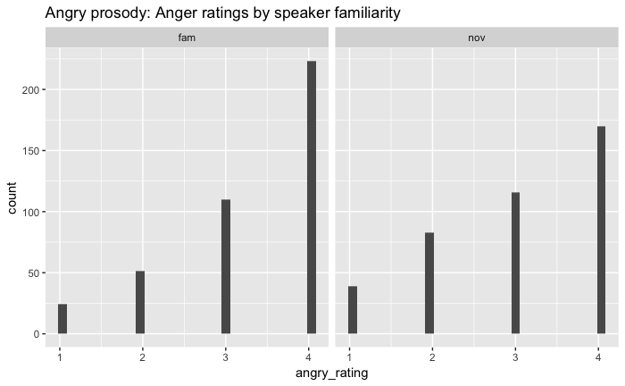

```r
peep2.df %>%
  filter(target_prosody %in% "ang") %>%
  ggplot() +
  # aes(x = script_name, y = angry_rating) +
  # geom_violin() +
  # facet_grid(. ~ script_variation) +
  aes(x = angry_rating) +
  geom_histogram() +
  facet_grid(. ~ speaker_famnov) +
  ggtitle("Angry prosody: Anger ratings by speaker familiarity")
```

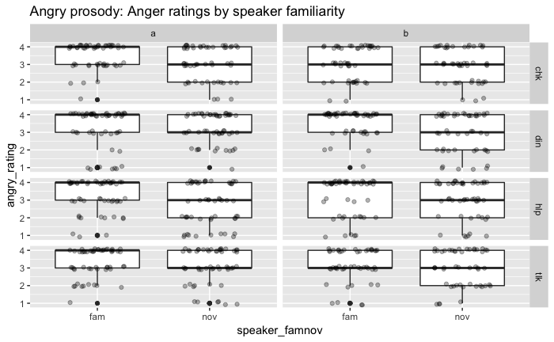

```r
peep2.df %>%
  filter(target_prosody %in% "ang") %>%
  ggplot() +
  aes(x = speaker_famnov, y = angry_rating) +
  geom_boxplot() +
  geom_jitter(width = 0.25, height = 0.1, alpha = 0.3) +
  facet_grid(script_name ~ script_variation) +
  ggtitle("Angry prosody: Anger ratings by speaker familiarity")
```

### Happy ratings

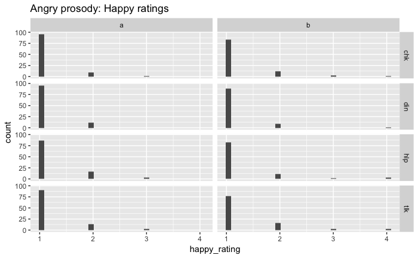

```r
peep2.df %>%
  filter(target_prosody %in% "ang") %>%
  ggplot() +
  # aes(x = script_name, y = happy_rating) +
  # geom_violin() +
  # facet_grid(. ~ script_variation) +
  aes(x = happy_rating) +
  geom_histogram() +
  facet_grid(script_name ~ script_variation) +
  ggtitle("Angry prosody: Happy ratings")
```

Again, let’s look at this by familiarity.

```r
peep2.df %>%
  filter(target_prosody %in% "ang") %>%
  ggplot() +
  # aes(x = script_name, y = happy_rating) +
  # geom_violin() +
  # facet_grid(. ~ script_variation) +
  aes(x = happy_rating) +
  geom_histogram() +
  facet_grid(. ~ speaker_famnov) +
  ggtitle("Angry prosody: Happy ratings by speaker familiarity")
```

[output not shown]

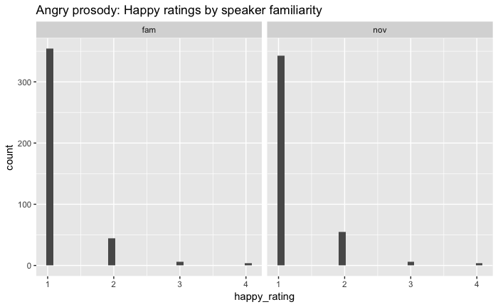

```r
peep2.df %>%
  filter(target_prosody %in% "ang") %>%
  ggplot() +
  # aes(x = script_name, y = happy_rating) +
  # geom_violin() +
  # facet_grid(. ~ script_variation) +
  aes(x = happy_rating) +
  geom_histogram() +
  facet_grid(. ~ speaker_famnov) +
  ggtitle("Angry prosody: Happy ratings by speaker familiarity")
```

### Sad ratings

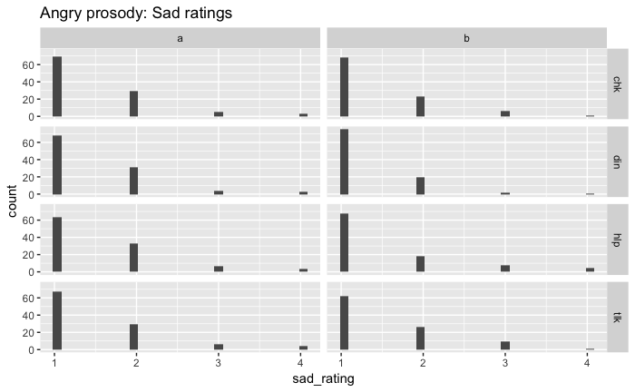

```r
peep2.df %>%
  filter(target_prosody %in% "ang") %>%
  ggplot() +
  # aes(x = script_name, y = sad_rating) +
  # geom_violin() +
  # facet_grid(. ~ script_variation) +
  aes(x = sad_rating) +
  geom_histogram() +
  facet_grid(script_name ~ script_variation) +
  ggtitle("Angry prosody: Sad ratings")
```

By speaker familiarity…

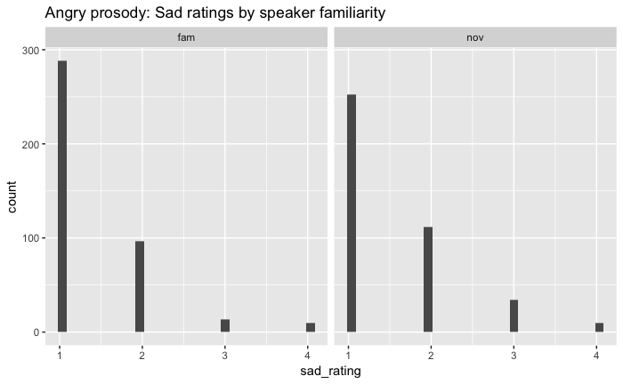

```r
peep2.df %>%
  filter(target_prosody %in% "ang") %>%
  ggplot() +
  # aes(x = script_name, y = sad_rating) +
  # geom_violin() +
  # facet_grid(. ~ script_variation) +
  aes(x = sad_rating) +
  geom_histogram() +
  facet_grid(. ~ speaker_famnov) +
  ggtitle("Angry prosody: Sad ratings by speaker familiarity")
```

### Scared ratings

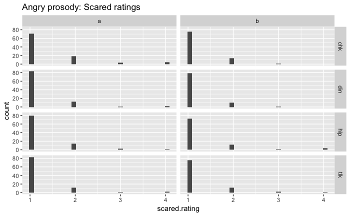

```r
peep2.df %>%
  filter(target_prosody %in% "ang") %>%
  ggplot() +
  # aes(x = script_name, y = scared.rating) +
  # geom_violin() +
  # facet_grid(. ~ script_variation) +
  aes(x = scared.rating) +
  geom_histogram() +
  facet_grid(script_name ~ script_variation) +
  ggtitle("Angry prosody: Scared ratings")
```

### How feel ratings

The `how_feel` variable codes on a [1,5] scale the participant’s response to the question: ‘How did this make you feel?’

The mapping from facial expression to image exemplar was as follows: 1 = neutral, 2 = mid-happy, 3 = mid-angry, 4= mid-sad, 5 = mid-scared.

Let’s add these labels to the `how_feel` so it’s easier to see the pattern.

```r
f <- factor(peep2.df$how_feel)
levels(f) <- c(NA, 'neu', 'hap', 'ang', 'sad', 'sca')
peep2.df$how_feel <- f
```

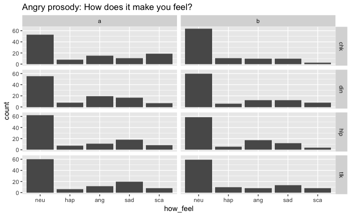

```r
peep2.df %>%
  filter(target_prosody %in% "ang") %>%
  ggplot() +
  # aes(x = script_name, y = how_feel) +
  # geom_violin() +
  # facet_grid(. ~ script_variation) +
  aes(x = how_feel) +
  geom_bar() +
  facet_grid(script_name ~ script_variation) +
  ggtitle("Angry prosody: How does it make you feel?")
```

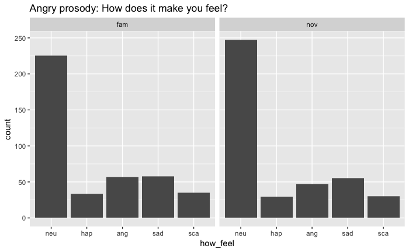

```r
peep2.df %>%
  filter(target_prosody %in% "ang") %>%
  ggplot() +
  # aes(x = script_name, y = how_feel) +
  # geom_violin() +
  # facet_grid(. ~ script_variation) +
  aes(x = how_feel) +
  geom_bar() +
  facet_grid(. ~ speaker_famnov) +
  ggtitle("Angry prosody: How does it make you feel?")
```

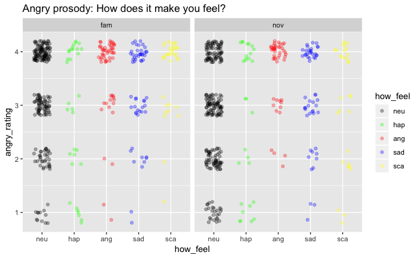

```r
peep2.df %>%
  filter(target_prosody %in% "ang",
         how_feel %in% c('neu', 'hap', 'ang', 'sad', 'sca')) %>%
  ggplot() +
  aes(x = how_feel, y = angry_rating, color = how_feel) +
  geom_jitter(width = 0.25, height = 0.20, alpha=0.3) +
  facet_grid(. ~ speaker_famnov) +
  ggtitle("Angry prosody: How does it make you feel?") +
  scale_colour_manual(values = emo_colors)
```

Participants feel largely neutral about the angry voices, with a bit of anger and sadness.

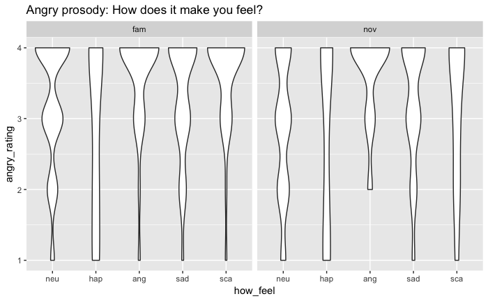

```r
peep2.df %>%
  filter(target_prosody %in% "ang") %>%
  ggplot() +
  aes(x = how_feel, y = angry_rating) +
  geom_violin() +
  facet_grid(. ~ speaker_famnov) +
  ggtitle("Angry prosody: How does it make you feel?")
```

Remember…

Neutral

Happy

Angry

Sad

Scared

1

2

3

4

5

## Happy prosody

### Happy ratings

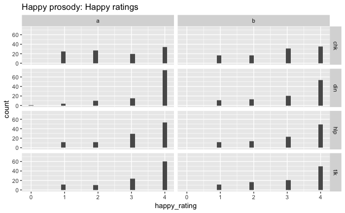

```r
peep2.df %>%
  filter(target_prosody %in% "hap") %>%
  ggplot() +
  # aes(x = script_name, y = happy_rating) +
  # geom_violin() +
  # facet_grid(. ~ script_variation) +
  aes(x = happy_rating) +
  geom_histogram() +
  facet_grid(script_name ~ script_variation) +
  ggtitle("Happy prosody: Happy ratings")
```

By speaker…

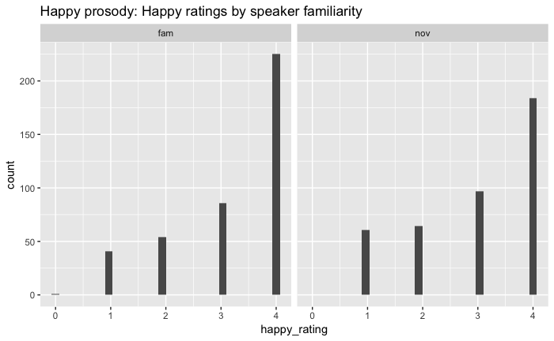

```r
peep2.df %>%
  filter(target_prosody %in% "hap") %>%
  ggplot() +
  # aes(x = script_name, y = happy_rating) +
  # geom_violin() +
  # facet_grid(. ~ script_variation) +
  aes(x = happy_rating) +
  geom_histogram() +
  facet_grid(. ~ speaker_famnov) +
  ggtitle("Happy prosody: Happy ratings by speaker familiarity")
```

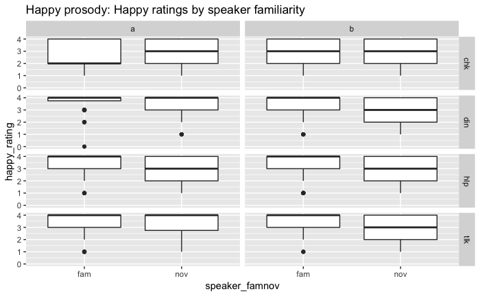

```r
peep2.df %>%
  filter(target_prosody %in% "hap") %>%
  ggplot() +
  aes(x = speaker_famnov, y = happy_rating) +
  geom_boxplot() +
  facet_grid(script_name ~ script_variation) +
  ggtitle("Happy prosody: Happy ratings by speaker familiarity")
```

### Angry ratings

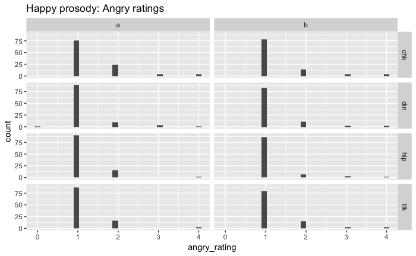

```r
peep2.df %>%
  filter(target_prosody %in% "hap") %>%
  ggplot() +
  # aes(x = script_name, y = angry_rating) +
  # geom_violin() +
  # facet_grid(. ~ script_variation) +
  aes(x = angry_rating) +
  geom_histogram() +
  facet_grid(script_name ~ script_variation) +
  ggtitle("Happy prosody: Angry ratings")
```

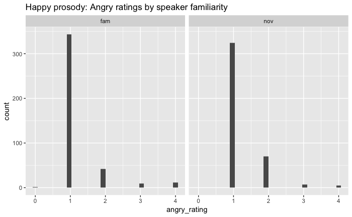

```r
peep2.df %>%
  filter(target_prosody %in% "hap") %>%
  ggplot() +
  # aes(x = script_name, y = angry_rating) +
  # geom_violin() +
  # facet_grid(. ~ script_variation) +
  aes(x = angry_rating) +
  geom_histogram() +
  facet_grid(. ~ speaker_famnov) +
  ggtitle("Happy prosody: Angry ratings by speaker familiarity")
```

### Sad ratings

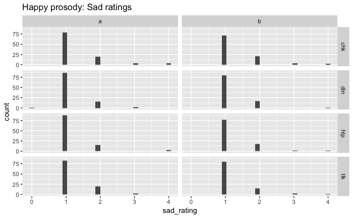

```r
peep2.df %>%
  filter(target_prosody %in% "hap") %>%
  ggplot() +
  # aes(x = script_name, y = sad_rating) +
  # geom_violin() +
  # facet_grid(. ~ script_variation) +
  aes(x = sad_rating) +
  geom_histogram() +
  facet_grid(script_name ~ script_variation) +
  ggtitle("Happy prosody: Sad ratings")
```

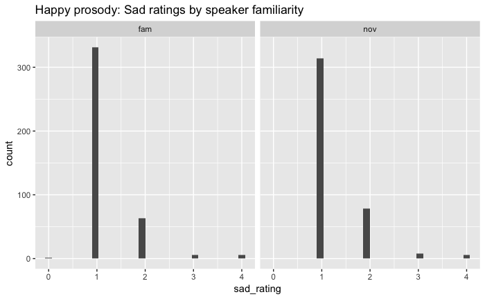

```r
peep2.df %>%
  filter(target_prosody %in% "hap") %>%
  ggplot() +
  # aes(x = script_name, y = sad_rating) +
  # geom_violin() +
  # facet_grid(. ~ script_variation) +
  aes(x = sad_rating) +
  geom_histogram() +
  facet_grid(. ~ speaker_famnov) +
  ggtitle("Happy prosody: Sad ratings by speaker familiarity")
```

### Scared ratings

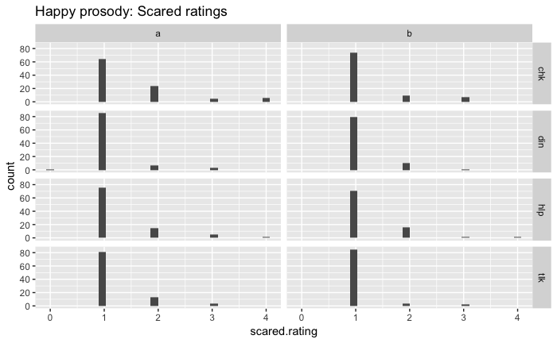

```r
peep2.df %>%
  filter(target_prosody %in% "hap") %>%
  ggplot() +
  # aes(x = script_name, y = scared.rating) +
  # geom_violin() +
  # facet_grid(. ~ script_variation) +
  aes(x = scared.rating) +
  geom_histogram() +
  facet_grid(script_name ~ script_variation) +
  ggtitle("Happy prosody: Scared ratings")
```

### How feel ratings

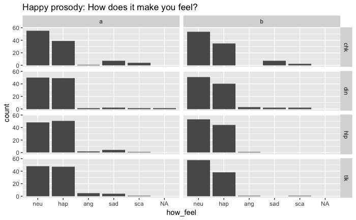

```r
peep2.df %>%
  filter(target_prosody %in% "hap") %>%
  ggplot() +
  # aes(x = script_name, y = how_feel) +
  # geom_violin() +
  # facet_grid(. ~ script_variation) +
  aes(x = how_feel) +
  geom_bar() +
  facet_grid(script_name ~ script_variation) +
  ggtitle("Happy prosody: How does it make you feel?")
```

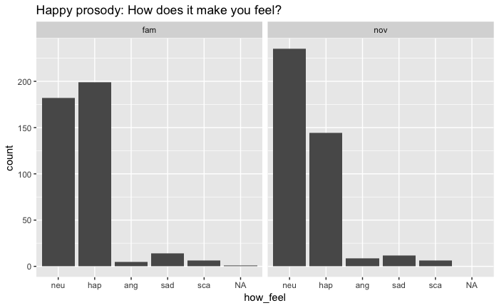

```r
peep2.df %>%
  filter(target_prosody %in% "hap") %>%
  ggplot() +
  aes(x = how_feel) +
  geom_bar() +
  facet_grid(. ~ speaker_famnov) +
  ggtitle("Happy prosody: How does it make you feel?")
```

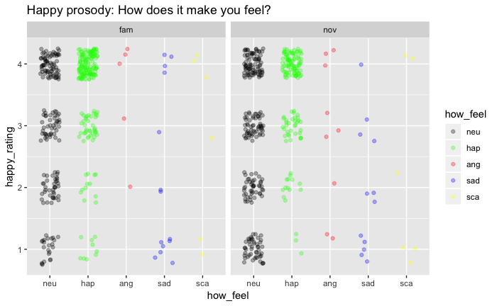

```r
peep2.df %>%
  filter(target_prosody %in% "hap",
         how_feel %in% c('neu', 'hap', 'ang', 'sad', 'sca')) %>%
  ggplot() +
  aes(x = how_feel, y = happy_rating, color = how_feel) +
  geom_jitter(width = 0.25, height = 0.25, alpha=0.3) +
  facet_grid(. ~ speaker_famnov) +
  ggtitle("Happy prosody: How does it make you feel?") +
  scale_colour_manual(values = emo_colors)
```

Participants feel largely happy or neutral about the happy prosodies, with more neutral feelings about the unfamiliar speaker.